# R for Stats

Alexey Abramov

10/9/2020

# Setup

```r
library(tidyverse)
```

```r
library(readr)
library(pwr)


knitr::opts_chunk$set(
  fig.width = 6,
  fig.asp = .6,
  out.width = "90%"
)

theme_set(
  ggthemes::theme_fivethirtyeight() + theme(legend.position = "bottom")
  )

options(
  ggplot2.continuous.colour = "viridis",
  ggplot2.continuous.colour = "viridis"
)

scale_colour_discrete = scale_color_viridis_d
scale_fill_discrete = scale_fill_viridis_d
```

# Binomial distribution

The probability that a patient fails to follow up in a given month is 15%. A pilot study is conducted to assess feasibility involving 5 patients.

To obtain a binomial probability for a single X value: dbinom(x, n, p)

To obtain a probability for values less than or equal to X: pbinom(x, n, p)

# Poisson Distribution

Example: The emergency room at CUMC receives an average of 7.5 patients each hour.

To obtain a poisson probability for a single X value in R: dpois(x, lambda)

To obtain a probability for values less than or equal to X in R: ppois(x, lambda)

# Bootstrapping

## read in the data

```r
wloss_data = read_table("./data/Weightloss20.txt")
```

### define the object with the values of interest

```r
loss = wloss_data$loss
```

### let’s look at a histogram of the loss values

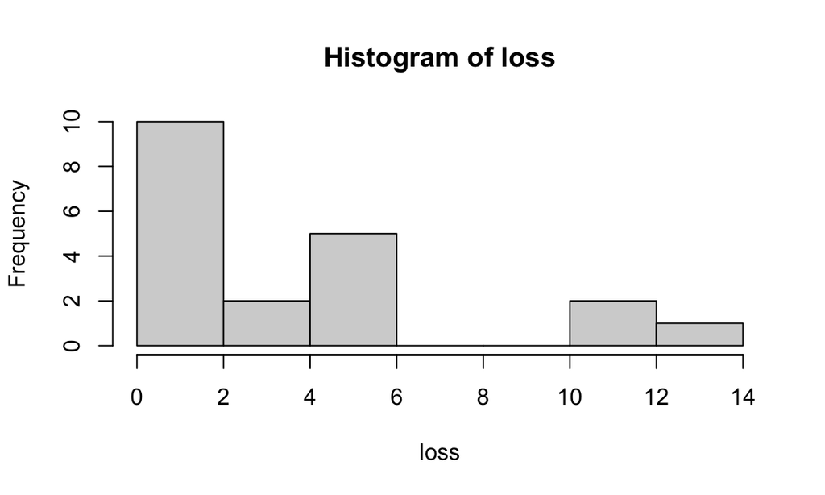

```r
hist(loss)
```

### compute the sample statistic from the observed sample

```r
xbar <- mean(loss)
xbar
```

```
## [1] 3.702
```

### how to draw one bootstrap sample

```r
sample(loss, size = 20, replace = T)
```

```
##  [1]  1.99 10.27  4.63 10.26  0.15  0.84  5.69  0.07  3.32  1.43  1.24 10.27
## [13]  3.32  5.43 10.27  0.39  0.07  5.43  0.53 10.27
```